# Fordgo Bike System Dataset 2018

by Shubhashri Chavan

# Investigation Overview

> - Fordgo Bike is a public bike sharing system that provides bike service in San Francisco. Overall 1863721 entries were gathered from the FordGo Bike dataset belonging to the year 2018 to carry out the analysis. It contains the trip data about all the bike riders as the bike_id, start_station,end_station and many other fields. Furthermore, it also preserves the data about the bike riders as-in the type of user i'e., customer or subscriber, gender and birth_year.

# Dataset Overview

- Monthly data of 2018 was collected and merged together to form the master dataset for carrying out analysis. The data was cleaned and the outliers affecting the visualizations were stripped off for a clean visualization. The graphs had to go through some tweaks for observing the data closely. Various trends in the data were observed during the exploration analysis phase which later led to communicate the major findings of the data.

## Univariate Exploration

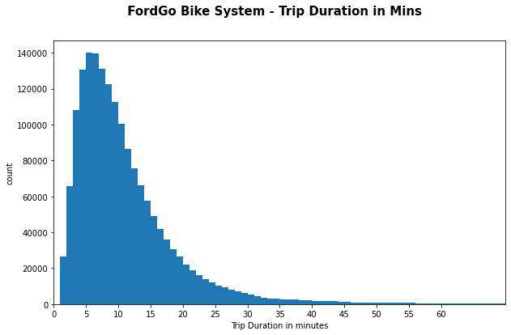

```python
plt.figure(figsize=(10,6));
bins=np.arange(0,bike_data['duration_mins'].max()+1,1)
xticks=[0,5,10,15,20,25,30,35,40,45,50,55,60]
labels=['{}'.format(v) for v in xticks]
plt.xlim(0,70)
plt.hist(data=bike_data,x='duration_mins',bins=bins);
plt.xticks(xticks,labels);
plt.xlabel('Trip Duration in minutes');
plt.ylabel('count');
plt.suptitle(' FordGo Bike System - Trip Duration in Mins',fontsize=15,fontweight='bold');
```

### Here, we observe that the histogram is right skewed. We also see, how the frequency for the minutes >8 starts falling down wedge by wedge. This depicts that the fordgobike rental is preferably chosen by the users to travel a short distance.

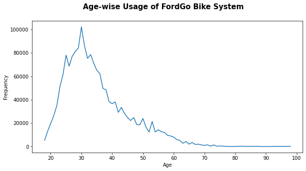

```python
# Removing the entries having age>100 (outliers)
bike_data=bike_data[bike_data['age']<=100]

plt.figure(figsize=(10,5));
bike_data['age'].value_counts().sort_index().plot.line()
plt.xlabel('Age');
plt.ylabel('Frequency');
plt.suptitle('Age-wise Usage of FordGo Bike System',fontsize=15,fontweight='bold');
```

## The frequency of bike hiring falls down with the increase in age. There seems to be an elevation in the bike hiring for age group (18-32). This suggests us that the bike is hired more by the young generation than people above 32.

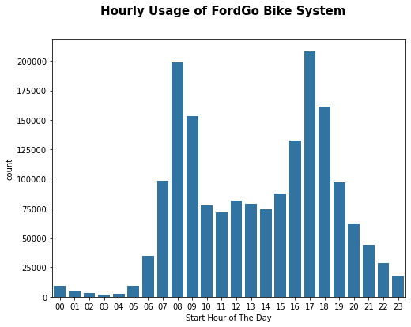

```python
plt.figure(figsize=(8,6));
color=sb.color_palette()[0]
sb.countplot(data = bike_data, x ='start_hour_of_the_day',color=color);
plt.xlabel('Start Hour of The Day');
plt.suptitle('Hourly Usage of FordGo Bike System',fontsize=15,fontweight='bold');
```

## The count of bike rentals is enormously high at 8 in the morning and 5 in the afternoon. This suggests that most of the bikes are hired by daily office going folks, the reason being the bikes getting hired mostly at the start of office hours and when the office gets over.

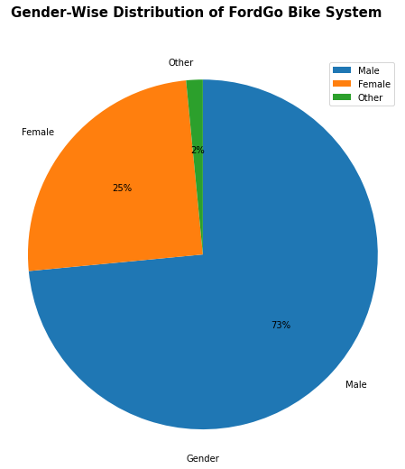

```python
# code for the pie chart seen above
plt.figure(figsize=(8,8));
counts = bike_data['member_gender'].value_counts()
plt.pie(counts, labels = counts.index, startangle = 90,
        counterclock = False,autopct='%1.0f%%');
plt.axis('square');
plt.xlabel('Gender');
plt.suptitle('Gender-Wise Distribution of FordGo Bike System',fontsize=15,fontweight='bold');
plt.legend();
```

### The piechart plotted above shows the gender wise distribution of data. It becomes clear from the piechart that the percentage of females hiring bikes is far less than the males that is only 25% whereas males account for 73% of the total distribution and Others as less as 2%.

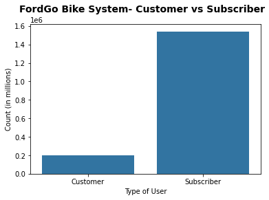

```python
base_color=sb.color_palette()[0]
sb.countplot(data=bike_data,x='user_type',color=base_color);
plt.xlabel('Type of User');
plt.ylabel('Count (in millions)');
plt.suptitle('FordGo Bike System- Customer vs Subscriber',fontsize=14,fontweight='bold');
```

### The plot above depicts that the no. of subscribers/members hiring the bike rentals is more than the customers availing the bike service.

## Bivariate Distribution

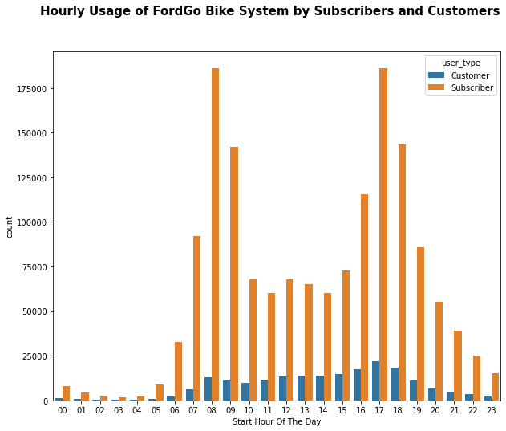

```python
plt.figure(figsize=(10,8));
sb.countplot(data=bike_data,x='start_hour_of_the_day',hue='user_type');
plt.xlabel('Start Hour Of The Day');
plt.suptitle('Hourly Usage of FordGo Bike System by Subscribers and Customers',fontsize=15,fontweight='bold');
```

### It is evident from the countplot above that no matter what hour of the day it is, the subscriber count is always going to be higher than the customer count. The customers renting the bikes is high at 5 in the afternoon whereas, for subscribers it is high at 8 in the morning and 5 in the afternoon. Another observation here is, the bike frequency is too low in the ealy morning around 4 which means that the FordGoBike Service is not availed for early morning rides but it is more inclined towards daily trips for work.

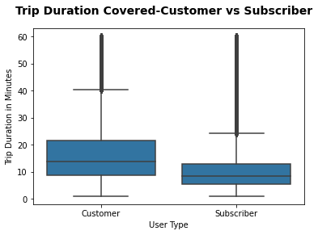

```python
temp_data=bike_data.query('duration_mins<=60')
base_color=sb.color_palette()[0]
sb.boxplot(data=temp_data, x='user_type', y='duration_mins',color=base_color);
plt.xlabel('User Type');
plt.ylabel('Trip Duration in Minutes');
plt.suptitle('Trip Duration Covered-Customer vs Subscriber',fontsize=14,fontweight='semibold');
```

### Although, the subscribers are likely to hire more bikes than the customer,it is clear from the above boxplot that the journey taken by customers is long than that of the subscribers.

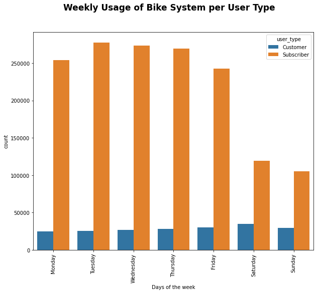

```python
plt.figure(figsize=(10,8))
order=['Monday','Tuesday','Wednesday','Thursday','Friday','Saturday','Sunday']
sb.countplot(data=bike_data,x='day_of_the_week',hue='user_type',order=order)
plt.xticks(rotation=90);
plt.xlabel('Days of the week');
plt.suptitle('Weekly Usage of Bike System per User Type',fontweight='bold',fontsize=17);
```

### From the above plot, the decline in bike-rentals by the subscribers on weekends is so obvious to the eye whereas, the graph doesn't show much change for the customers. This suggests that, all the subscribers are job-going folks whereas the customers hire bike for their leisure pursuits. The graph for customer shows a minor inclination towards Saturdays. That being said, the customers are in no hurry and usually go out for rides on weekends to visit places in and around the city. Also, no matter what day of the week it is, subscriber count is always going to be higher than the customer count. Another thing to notice over here is, 'Tuesday' has highest no of riders out of all the days.

## Multivariate Exploration

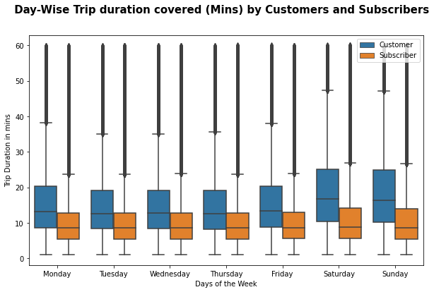

```python
plt.figure(figsize=(10,6))
temp=bike_data[bike_data['duration_mins']<=60]
order=['Monday','Tuesday','Wednesday','Thursday','Friday','Saturday','Sunday']
ax=sb.boxplot(x='day_of_the_week',y='duration_mins',hue='user_type',data=temp,order=order);
ax.legend(framealpha=1);
plt.xlabel('Days of the Week');
plt.ylabel('Trip Duration in mins');
plt.suptitle(' Day-Wise Trip duration covered (Mins) by Customers and Subscribers', fontweight='bold',fontsize=15);
plt.legend(loc='upper right');
```

### We can very well observe an elevation from weekdays to weekends for the duration of journey covered by the customers which means, the customers take even long trips on weekends compared to weekdays. However, we are uncertain about the trend that follows for the Subscribers from weekdays to weekends since this graph does not show much of a difference.

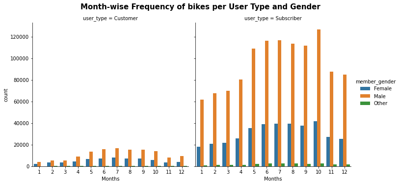

```python
g=sb.catplot(data=bike_data, x='start_month_no', col="user_type", hue="member_gender", kind='count');
plt.suptitle('Month-wise Frequency of bikes per User Type and Gender', fontweight='bold',fontsize=15,y=1.04);
g.set_axis_labels("Months");
```

## The catplot clearly depicts that the no. of subscriber users is way more than that of the customer users. A pattern can be observed here, how the customers increase in number from January till July and then slowly, the graph goes down till the last month. Whereas, the subscriber count goes substantially high in the month of October. Another noticable patern over here is that regardless of the month, male count is always the highest.

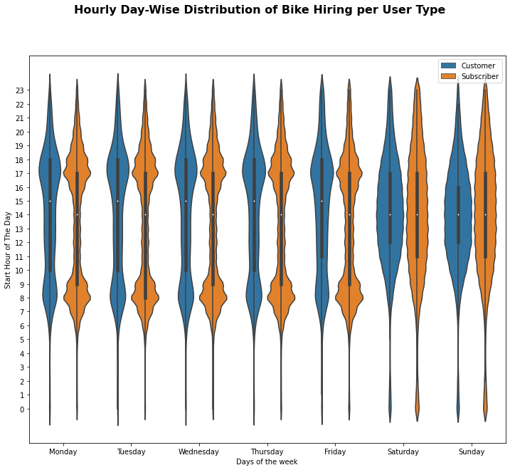

```python
bike_data['start_hour_of_the_day']=bike_data['start_hour_of_the_day'].astype(int)
plt.figure(figsize=(12,10));
sb.violinplot(x='day_of_the_week',y='start_hour_of_the_day',hue='user_type',data=bike_data,order=order);
yticks=[0,1,2,3,4,5,6,7,8,9,10,11,12,13,14,15,16,17,18,19,20,21,22,23]
labels=['{}'.format(v) for v in yticks]
plt.yticks(yticks,labels);
plt.suptitle('Hourly Day-Wise Distribution of Bike Hiring per User Type', fontweight='bold',fontsize='16');
plt.xlabel('Days of the week')
plt.ylabel('Start Hour of The Day');
plt.legend();
```

### The clear picture is finally here. The violin plot above has a lot of interesting data to consume in.

## Subscribers :

### The subscribers count seems bulging during the morning hours 8-9 (maximum at 8 a.m). The violin plot goes flattening post 10 a.m till 3 p.m. and again starts swelling out till 5.30 p.m(maximum at 5 p.m) which pretty much suggests that they are working professionals who hire bikes for going to and from home for work. A noticable aspect here is that on weekends there is quite a less frequency of bikes being hired by the subscribers both on 9 in the morning or 5 in the evening. The reason being that they are tired working whole week and want to get some rest on weekends.

## Customers :

### The frequency of bikes being hired by customers in office hours is fairly less on weekdays whereas, they have maximum bike hiring post 5 pm on the weekdays probably to collect vegetables from the market or some other work. The customers on weekends and prefer going out post 12 in the afternoon for roaming in and around the city on weekdays.